# Spatio-temporal Modelling, Lab 8 2023-12-13

**This exercise will be discussed on 2023-12-20.**

# 1 Universal kriging

Universal kriging

Just like stratified kriging, universal kriging provides a less restrictive model than ordinary kriging. Suppose the model for ordinary kriging is written as
$$Z(s)=m+e(s)$$
with $Z(s)$ the observed variable $Z$ at spatial location $s$, $m$ a constant but unknown mean value and $e(s)$ an intrinsically stationary residual, we can write stratified kriging as $j$ models

$$Z_j(s)=m_j+e_j(s),$$

$j$ referring to the stratum: each stratum has a different mean and different parameters describing the spatial correlation of $e_j$, and $e_j(s)$ and $e_k(s)$ are independent if $j!=k$.

Universal kriging extends the ordinary kriging model by replacing the constant mean value by a non-constant mean function:

$$Z(s)=\beta_0+\beta_1X_1(s)+...+\beta_pX_p(s)+e(s)$$
with $\beta_j$ the trend (i.e., regression) coefficients, and $X_j(s)$ $p$ known predictor functions (independent variables, regressors).

The hope is that the predictor functions carry information in them that explains the variability of $Z(s)$ to a considerable extent, in which case the residual $e(s)$ will have lower variance and less spatial correlation compared to the ordinary kriging case. To see that this model extends ordinary kriging, take $p=0$ and note that for that case $\beta_0=m$. Another simplification is that if $e(s)$ is spatially independent, the universal kriging model reduces to a multiple linear regression model. One problem with universal kriging is that we need the variogram of the residuals, without having measured the residuals.

As we’ve seen before, we can predict the zinc concentrations fairly well from the sqrt-transformed values of distance to river:

**sp**

```r
library(gstat)
library(sp)
library(rgdal)
sp.theme(TRUE)
meuse <- readOGR("./data/meuse.gpkg")
meuse.riv <- readOGR("./data/meuse_river.gpkg")
meuse.lt = list(riv = list("sp.polygons", meuse.riv, fill = "grey"), pts = list("sp.points",
    meuse, pch = 3, cex = 0.5, col = "black"))
meuse.grid <- as(readGDAL("./data/meuse_grid.tif"),"SpatialPixelsDataFrame")
```

```
./data/meuse_grid.tif has GDAL driver GTiff
and has 104 rows and 78 columns
```

```r
names(meuse.grid) <- c("part.a","part.b","dist","soil","ffreq")
meuse.grid$soil <- as.factor(meuse.grid$soil)
meuse.grid$ffreq <- as.factor(meuse.grid$ffreq)
lzn.vgm = variogram(log(zinc) ~ 1, meuse)
lzn.mod = fit.variogram(lzn.vgm, vgm(0.6, "Sph", 1000, 0.05))
plot(log(zinc) ~ sqrt(dist), as.data.frame(meuse))
lzn.lm = lm(log(zinc) ~ sqrt(dist), as.data.frame(meuse))
summary(lzn.lm)
```

```
Call:
lm(formula = log(zinc) ~ sqrt(dist), data = as.data.frame(meuse))

Residuals:
     Min       1Q   Median       3Q      Max
-1.04624 -0.29060 -0.01869  0.26445  1.59685

Coefficients:
            Estimate Std. Error t value Pr(>|t|)
(Intercept)  6.99438    0.07593   92.12   <2e-16 ***
sqrt(dist)  -2.54920    0.15498  -16.45   <2e-16 ***
---
Signif. codes:  0 '***' 0.001 '**' 0.01 '*' 0.05 '.' 0.1 ' ' 1

Residual standard error: 0.4353 on 153 degrees of freedom
Multiple R-squared:  0.6388,    Adjusted R-squared:  0.6364
F-statistic: 270.6 on 1 and 153 DF,  p-value: < 2.2e-16
```

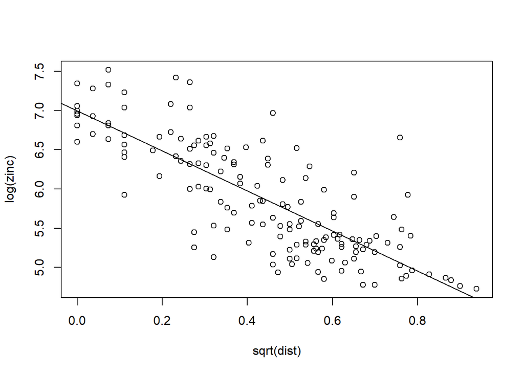

```r
abline(lzn.lm)
```

**sf/stars**

```r
library(gstat)
library(sf)
library(stars)
meuse.sf <- st_read("./data/meuse.gpkg")
meuse.riv.sf <- st_read("./data/meuse_river.gpkg")
meuse.grid.stars <- read_stars("./data/meuse_grid.tif")
meuse.grid.stars <- split(meuse.grid.stars, "band")
names(meuse.grid.stars) <- c("part.a","part.b","dist","soil","ffreq")
meuse.grid.stars$soil <- as.factor(meuse.grid.stars$soil)
meuse.grid.stars$ffreq <- as.factor(meuse.grid.stars$ffreq)
bpy.palette=bpy.colors()
lzn.vgm.sf = variogram(log(zinc) ~ 1, meuse.sf)
lzn.mod.sf = fit.variogram(lzn.vgm.sf, vgm(0.6, "Sph", 1000, 0.05))
plot(log(zinc) ~ sqrt(dist), as.data.frame(meuse.sf))
lzn.lm.sf = lm(log(zinc) ~ sqrt(dist), as.data.frame(meuse.sf))
summary(lzn.lm.sf)
```

```
Call:
lm(formula = log(zinc) ~ sqrt(dist), data = as.data.frame(meuse.sf))

Residuals:
     Min       1Q   Median       3Q      Max
-1.04624 -0.29060 -0.01869  0.26445  1.59685

Coefficients:
            Estimate Std. Error t value Pr(>|t|)
(Intercept)  6.99438    0.07593   92.12   <2e-16 ***
sqrt(dist)  -2.54920    0.15498  -16.45   <2e-16 ***
---
Signif. codes:  0 '***' 0.001 '**' 0.01 '*' 0.05 '.' 0.1 ' ' 1

Residual standard error: 0.4353 on 153 degrees of freedom
Multiple R-squared:  0.6388,    Adjusted R-squared:  0.6364
F-statistic: 270.6 on 1 and 153 DF,  p-value: < 2.2e-16
```

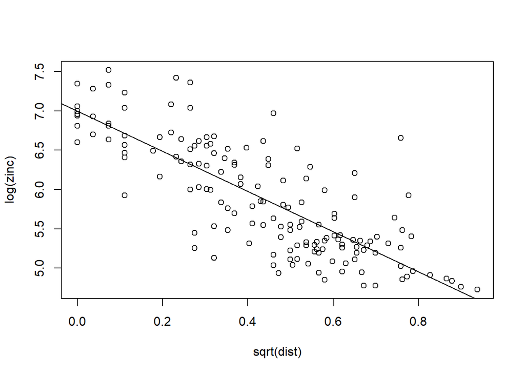

```r
abline(lzn.lm.sf)
```

To compare the variograms from raw (but log-transformed) data and regression residuals, look at the conditioning plot obtained by

**sp**

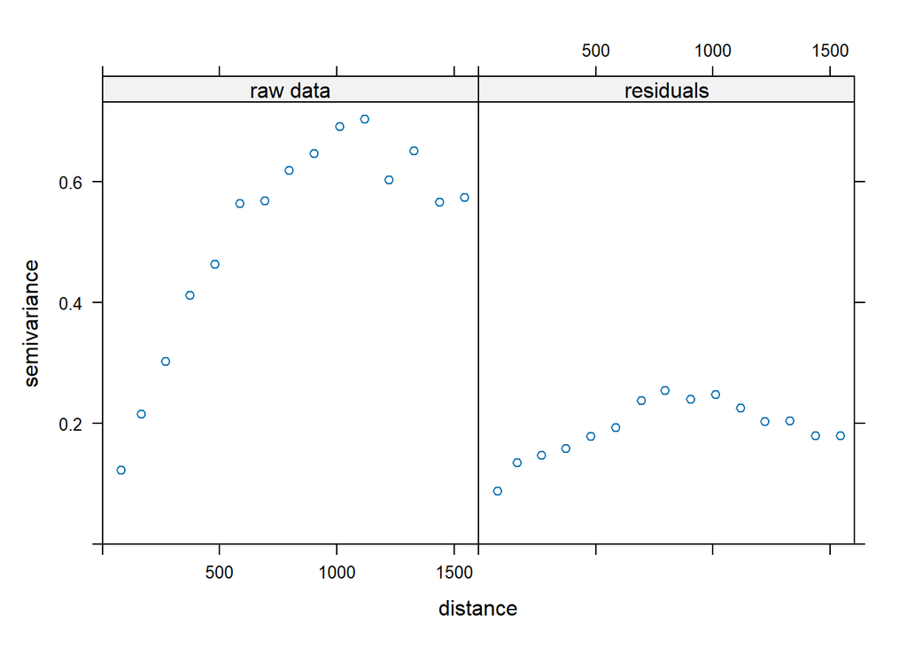

```r
g = gstat(id = "raw data", formula = log(zinc) ~ 1, data = meuse)
g = gstat(g, id = "residuals", formula = log(zinc) ~ sqrt(dist), data = meuse)
plot(variogram(g, cross = F), scales = list(relation = "same"), layout = c(2,
    1))
```

**sf/stars**

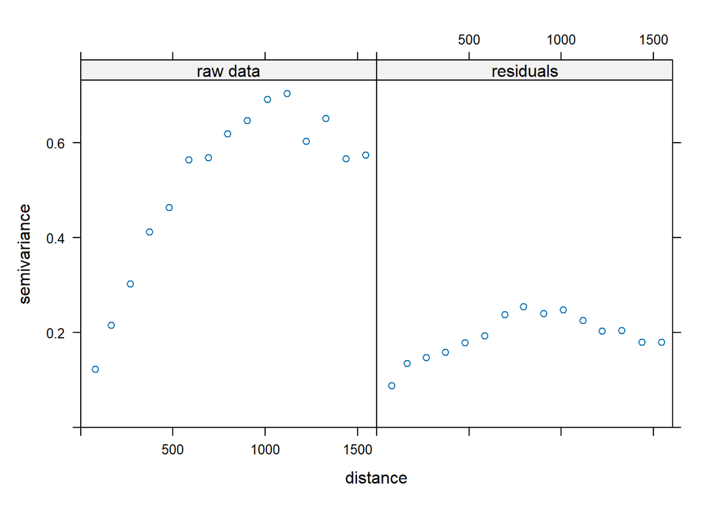

```r
g.sf = gstat(id = "raw data", formula = log(zinc) ~ 1, data = meuse.sf)
g.sf = gstat(g.sf, id = "residuals", formula = log(zinc) ~ sqrt(dist), data = meuse.sf)
plot(variogram(g.sf, cross = F), scales = list(relation = "same"), layout = c(2,
    1))
```

#### *Exercise 1*

**Exercise 1**

*How is the residual standard error from the regression model above (`lzn.lm`) related to the variogram of the residuals?*

1. it is half the mean semivariance of the raw data and that of the residuals
2. the square of the residual standard error (the residual variance) equals the sill of the residual variogram
3. it equals the range of the residual variogram
4. it equals the sill of the residual variogram
5. it equals the nugget of the residual variogram
6. the residual variance (approximately) equals the nugget of the variogram

#### *Exercise 2*

**Exercise 2**

*Why is the sill of the residual variogram much lower than the sill of the variogram for the raw data?*

1. residuals have less spatial correlation than original data
2. residuals vary less because here the regression model removed part of the total variability
3. the residuals have little in common with the (log) zinc data
4. residuals allways have much smaller variability than raw data

When a regression model formula is passed to `variogram`, the variogram of the residuals is calculated. When a model formula is passed to `krige`, universal kriging is used.

Now model the residual variogram with a spherical model, say `zn.res.m`, and apply universal kriging. Compare the maps with predictions from universal kriging and ordinary kriging.

**sp**

```r
v = variogram(log(zinc) ~ dist, meuse)
# fit residual variogram model
zn.res.m = fit.variogram(v, vgm(1, "Sph", 700, 1))
zn.res.m
```

```
  model      psill    range
1   Nug 0.07642396   0.0000
2   Sph 0.20529364 728.6812
```

```r
# universal kriging
outuk = krige(log(zinc) ~ dist, meuse, meuse.grid, model = zn.res.m)
```

```
[using universal kriging]
```

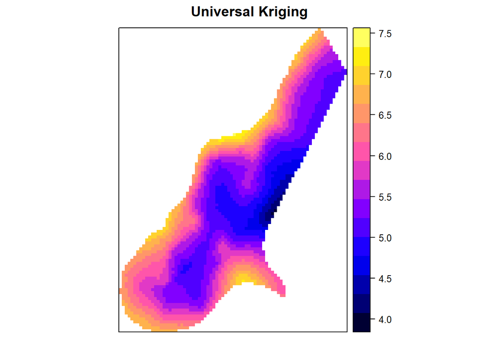

```r
spplot(outuk["var1.pred"], main = "Universal Kriging")
```

```r
# ordinary kriging
outok = krige(log(zinc) ~ 1, meuse, meuse.grid, model = lzn.mod)
```

```
[using ordinary kriging]
```

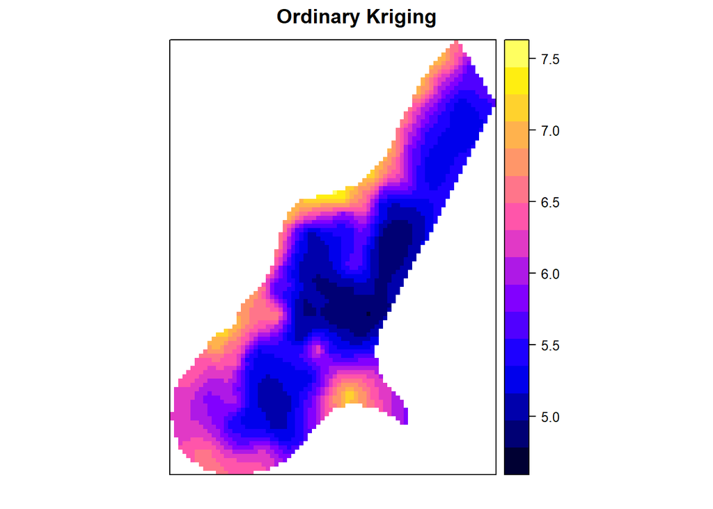

```r
spplot(outok["var1.pred"], main = "Ordinary Kriging")
```

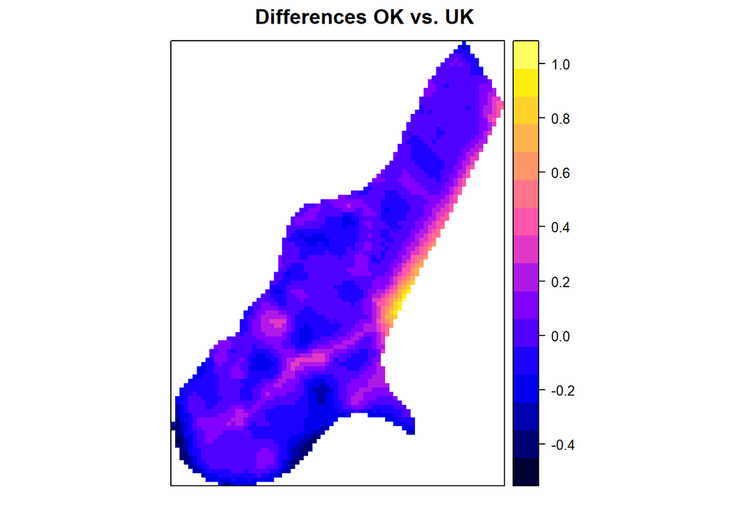

```r
# differences ordinary kriging vs. universal kriging
outuk$diff <- outok$var1.pred-outuk$var1.pred
spplot(outuk["diff"], main = "Differences OK vs. UK")
```

**sf/stars**

```r
library(tmap)
v.sf = variogram(log(zinc) ~ dist, meuse.sf)
# fit residual variogram model
zn.res.m.sf = fit.variogram(v.sf, vgm(1, "Sph", 700, 1))
zn.res.m.sf
```

```
  model      psill    range
1   Nug 0.07642396   0.0000
2   Sph 0.20529364 728.6812
```

```r
# universal kriging
outuk.stars = krige(log(zinc) ~ dist, meuse.sf, meuse.grid.stars, model = zn.res.m.sf)
```

```
[using universal kriging]
```

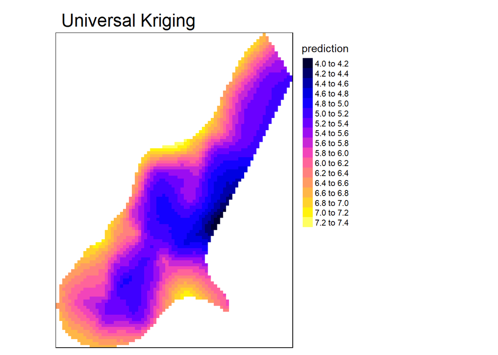

```r
tm_shape(outuk.stars) +
  tm_raster("var1.pred", n=20, title = "prediction", palette = bpy.palette) +
  tm_layout(main.title = "Universal Kriging", legend.outside = TRUE)
```

```r
# ordinary kriging
outok.stars = krige(log(zinc) ~ 1, meuse.sf, meuse.grid.stars, model = lzn.mod.sf)
```

```
[using ordinary kriging]
```

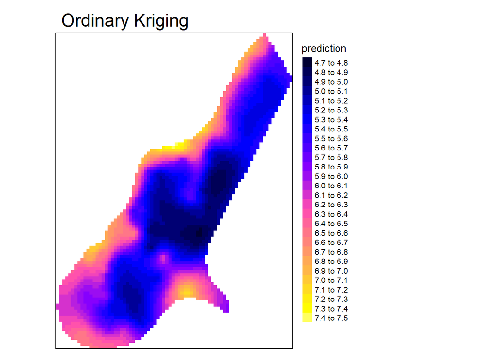

```r
tm_shape(outok.stars) +
  tm_raster("var1.pred", n=20, title = "prediction", palette = bpy.palette) +
  tm_layout(main.title = "Ordinary Kriging", legend.outside = TRUE)
```

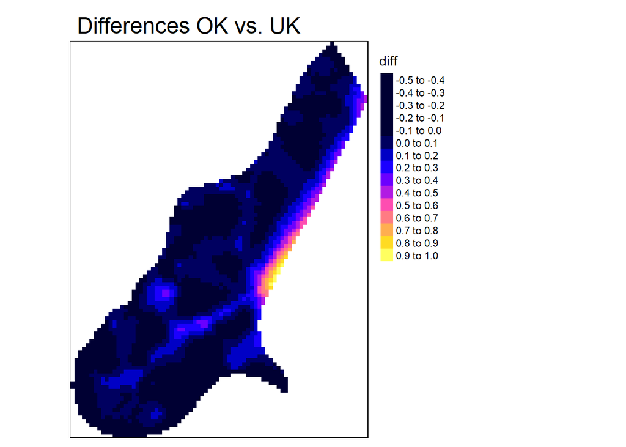

```r
# differences ordinary kriging vs. universal kriging
outuk.stars$diff <- outok.stars$var1.pred-outuk.stars$var1.pred
tm_shape(outuk.stars) +
  tm_raster("diff", n=20, title = "diff", palette = bpy.palette) +
  tm_layout(main.title = "Differences OK vs. UK", legend.outside = TRUE)
```

#### *Exercise 3*

**Exercise 3**

*Where are the differences most prevalent?*

1. In areas with values for `dist` close to 0 and 1
2. In areas with few data points
3. In areas where both (a) and (b) are valid

#### *Exercise 4*

**Exercise 4**

*Why are the differences happening exactly there?*

1. on locations far from measurements, interpolation relies heavily on the estimated trend value; where `dist` is close to 0 or 1, the trend value is most different from the value m used in ordinary kriging
2. on locations far from measurements we are most uncertain about the true values
3. on locations where `dist` is close to 0 or 1, it was hard to collect data, because these locations were hard to reach.

# 2 Block kriging

We will try block kriging settings under the universal kriging model. Note that the grid cell size of `meuse.grid` is 40:

**sp**

```r
gridparameters(meuse.grid)
```

```
  cellcentre.offset cellsize cells.dim
x            178460       40        78
y            329620       40       104
```

**sf/stars**

```r
st_dimensions(meuse.grid.stars)
```

```
  from  to offset delta              refsys point x/y
x    1  78 178440    40 Amersfoort / RD New FALSE [x]
y    1 104 333760   -40 Amersfoort / RD New FALSE [y]
```

meaning that blocks of size 400 are largely overlapping.

**sp**

```r
zn = krige(log(zinc) ~ sqrt(dist), meuse, meuse.grid, zn.res.m)
```

```
[using universal kriging]
```

```r
zn$pointkr = zn$var1.pred
zn40 = krige(log(zinc) ~ sqrt(dist), meuse, meuse.grid, zn.res.m, block = c(40,
    40))
```

```
[using universal kriging]
```

```r
zn400 = krige(log(zinc) ~ sqrt(dist), meuse, meuse.grid, zn.res.m, block = c(400,
    400))
```

```
[using universal kriging]
```

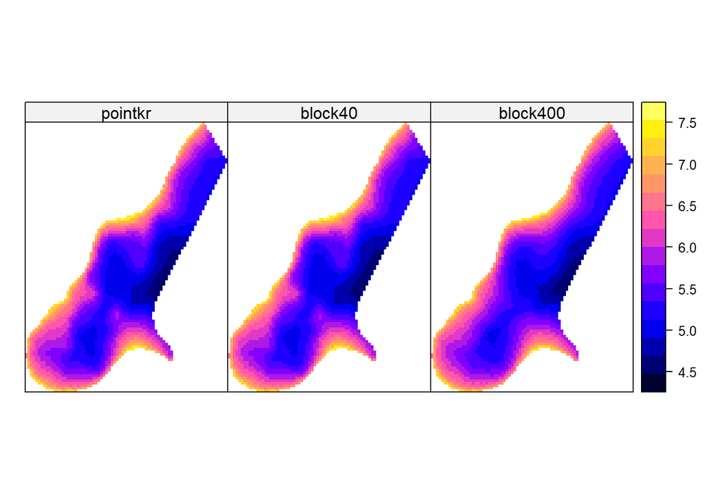

```r
zn$block40 = zn40$var1.pred
zn$block400 = zn400$var1.pred
spplot(zn[c("pointkr", "block40", "block400")], as.table = TRUE)
```

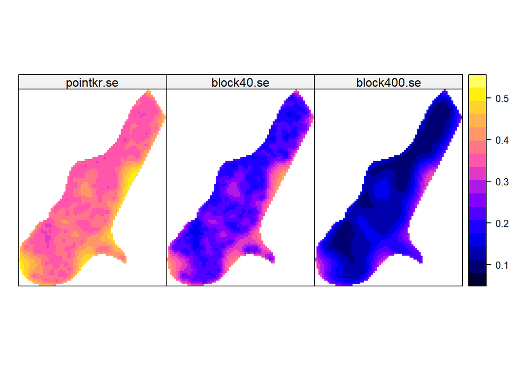

```r
zn$pointkr.se = sqrt(zn$var1.var)
zn$block40.se = sqrt(zn40$var1.var)
zn$block400.se = sqrt(zn400$var1.var)
spplot(zn[c("pointkr.se", "block40.se", "block400.se")], as.table = TRUE)
```

**sf/stars**

```r
zn.stars = krige(log(zinc) ~ sqrt(dist), meuse.sf, meuse.grid.stars, zn.res.m.sf)
```

```
[using universal kriging]
```

```r
zn.stars$pointkr = zn.stars$var1.pred
zn40.stars = krige(log(zinc) ~ sqrt(dist), meuse.sf, meuse.grid.stars, zn.res.m.sf, block = c(40,
    40))
```

```
[using universal kriging]
```

```r
zn400.stars = krige(log(zinc) ~ sqrt(dist), meuse.sf, meuse.grid.stars, zn.res.m.sf, block = c(400,
    400))
```

```
[using universal kriging]
```

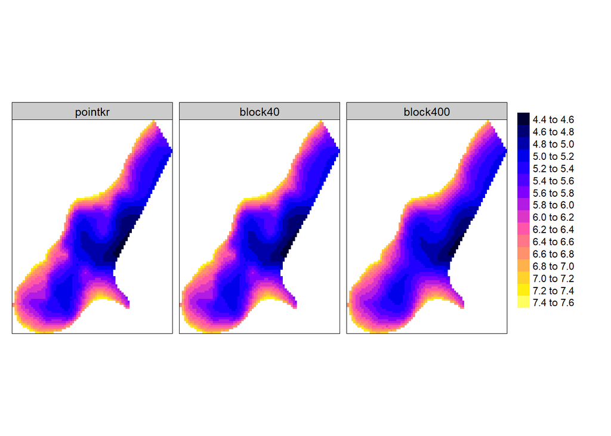

```r
zn.stars$block40 = zn40.stars$var1.pred
zn.stars$block400 = zn400.stars$var1.pred
tm_shape(zn.stars) +
  tm_raster(c("pointkr","block40","block400"), n=20, palette = bpy.palette, title="") +
  tm_facets(free.scales = FALSE) +
  tm_layout(legend.outside.size = 0.15, panel.labels = c("pointkr","block40","block400"))
```

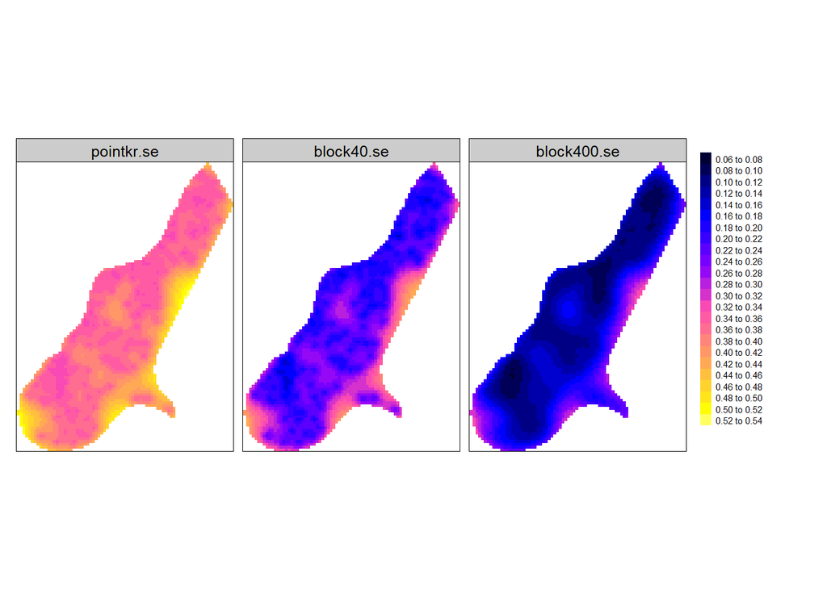

```r
zn.stars$pointkr.se = sqrt(zn.stars$var1.var)
zn.stars$block40.se = sqrt(zn40.stars$var1.var)
zn.stars$block400.se = sqrt(zn400.stars$var1.var)
tm_shape(zn.stars) +
  tm_raster(c("pointkr.se", "block40.se", "block400.se"), n=20, palette = bpy.palette, title="") +
  tm_facets(free.scales = FALSE) +
  tm_layout(legend.outside.size = 0.15, panel.labels = c("pointkr.se", "block40.se", "block400.se"))
```

#### *Exercise 5*

**Exercise 5**

*Describe what happens if we change from point prediction to block prediction of size 40, in terms of predictions and in terms of prediction standard errors?*

#### *Exercise 6*

**Exercise 6**

*Describe what happens if we change from block prediction for blocks of size 40 m to block prediction for blocks of size 400 m, in terms of predictions and in terms of prediction standard errors?*